# 2. Specific analysis

```r
library(readxl)
library(gplots)
library(pheatmap)
library(VennDiagram)
```

1. Step 1: Identification of genes as biomarker  
   1.1 Finding biomarker for cisplatin  
   1.2 Testing biomarker genes
2. Step 2: Biomarker gene expression
3. Step 3: Further evaluation of biomarker gene

## Step 1: Can we identify certain genes as biomarkers for cisplatin?

#### Step 1a: Finding Biomarkers for cisplatin

##### Criterium: High fold-change values throughout the cell lines

In the beginning of the specific analysis the gene expression values were scaled and the log2 fold changes were computed. For the downstream analysis the mean fold-change values across all cell lines treated with cisplatin were used.

```r
log2FC.treated.untreated <- (treated.scaled-untreated.scaled)
```

The applied criterium to identify certain genes as biomarkers for cisplatin is the expression fold change between tumor samples and treated tumor samples. The cisplatin treatment was the same for all cell lines: 15000nM and 24 hours. The genes, which showed the highest gene expression changes throughout all cell lines upon cisplatin pertubation also showed the most extreme fold change values. So, genes were ranked after their fold-change and the 20 highest and 20 lowest were selected.

The resulting genes and their expression fold-changes between tumor samples and treated tumor samples were visualized through a barplot.

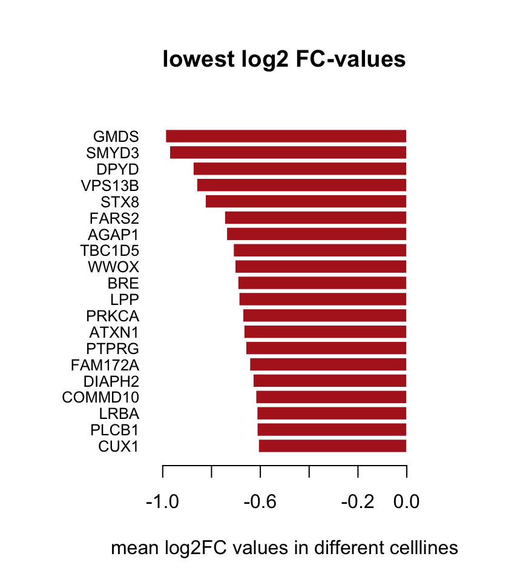

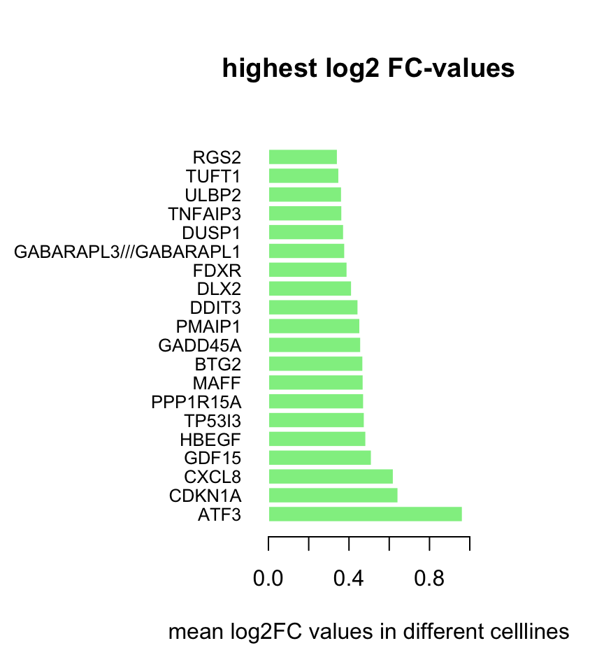

#### Additional criterium: Gene expression change in the same “direction”

```r
is.neg = FC.cisplatin<0
i =1
j=1
a=1
biomarker2.up = c()
biomarker2.down = c()
while(j<13300){
  while(i<56){
    if(is.neg[j,i]==TRUE)
     {a=a+1}
    i=i+1}
  if(a>49)
     {biomarker2.down= c(biomarker2.down, j)}
  if(a<6)
    {biomarker2.up= c(biomarker2.up, j)}
  a=1
  i=1
  j=j+1}
```

### Subselection of biomarkers found through the FC-criterium

The genes found through the FC-criterium (criterium 1) were subselected with our additional criterium, which reduced the previously found genes (40) to 15 biomarker genes. With the second criterium, additional information was added through including the consistent change of up or down regulation.

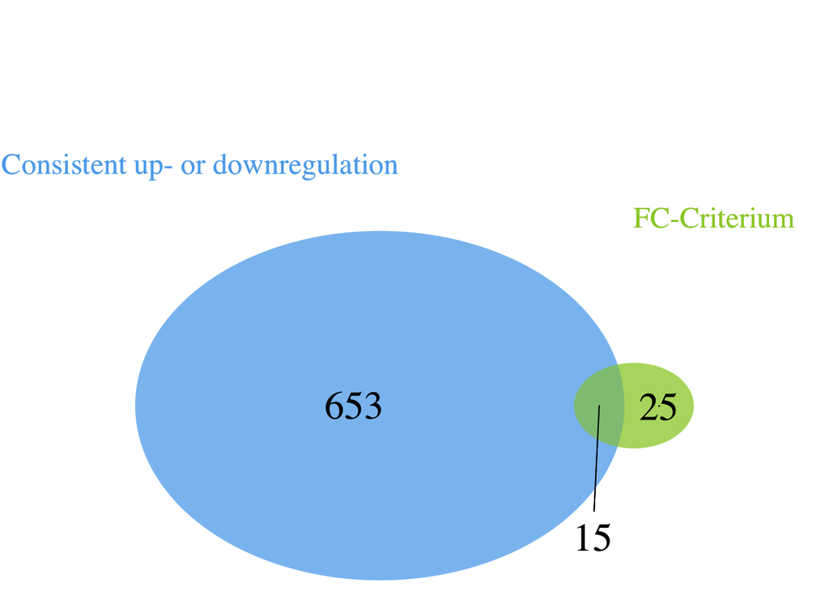

```r
print(double.biomarker)
```

```
##  [1] "CUX1"    "PLCB1"   "LRBA"    "COMMD10" "DIAPH2"  "FAM172A" "PTPRG"
##  [8] "ATXN1"   "PRKCA"   "LPP"     "BRE"     "AGAP1"   "FARS2"   "DPYD"
## [15] "GMDS"
```

## Step 1b: How significant are the genes previously identified as biomarker?

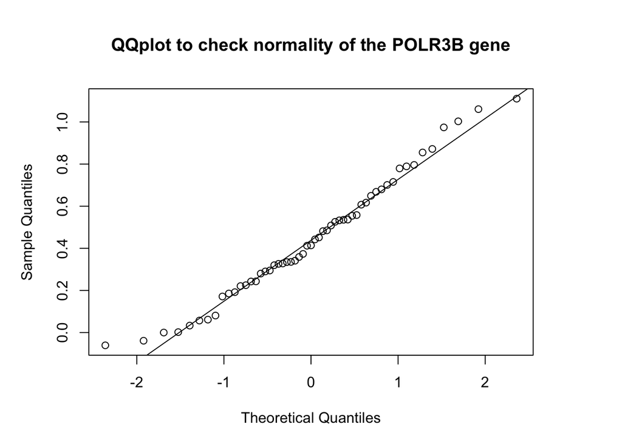

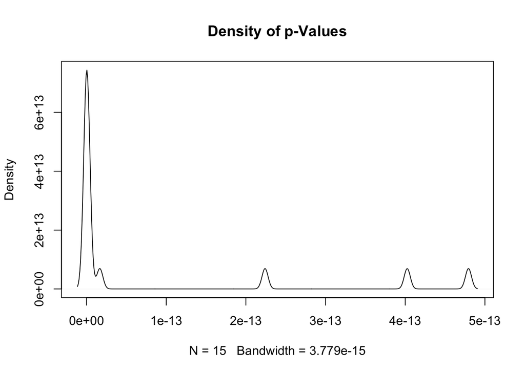

```r
pvalues.welch <- sapply(double.biomarker, function(x){
       t.test(treated.cisplatin[x,], untreated.cisplatin[x,],paired= T)$p.value
   })
plot(density(pvalues.welch), main = "Density of p-Values")
```

The resulting p-values indicate significant expressional change of biomarkers in all celllines upon cisplatin pertubation.

### Standard deviation to check consistency of fold-changes across cell lines

Furthermore, the fold-change values for biomarker genes upon cisplatin pertubation were related to their standard deviation.

```r
mean.double <- apply(double.biomarker.FC, 1, mean)
sd.double <- apply(double.biomarker.FC, 1, sd)
double = cbind(mean.double, sd.double)
colnames(double) = c("mean FC","SD" )
print(double)
```

```
##            mean FC        SD
## CUX1    -0.6082963 0.4771558
## PLCB1   -0.6137955 0.4790071
## LRBA    -0.6143459 0.3530860
## COMMD10 -0.6190894 0.2989394
## DIAPH2  -0.6301878 0.3516520
## FAM172A -0.6441424 0.2987363
## PTPRG   -0.6601049 0.4706693
## ATXN1   -0.6677068 0.4115036
## PRKCA   -0.6721456 0.4523083
## LPP     -0.6879913 0.3906371
## BRE     -0.6925710 0.3462126
## AGAP1   -0.7388173 0.5011920
## FARS2   -0.7469592 0.4040131
## DPYD    -0.8757969 0.6719183
## GMDS    -0.9887238 0.4405076
```

The resulting standard deviation values were higher than expected, meaning the fold-change values have a high variation between the different cell lines. A tissue based separation and selection of cancer types, which are regularly treated with cisplatin (testicular carcinoma, ovarian and bladder cancer), might result in fold-change values with less variance and also in different and more specific biomarker genes.

## Step 2: Influence of cisplatin on the biomarkers gene expression in different cell lines

#### Checking how many clusters will be needed in the heatmap (elbow plot)

Before the heatmap was computed, the optimal number of clusters was checked with an elbow plot. Unfortunately, the kmeans clustering results in a high within-sum-of-square value, indicating a bad clustering.

```r
wss = sapply(2:7,function(k) {
  kmeans(x = t(double.biomarker.FC), centers = k)$tot.withinss
})
kmeans= kmeans(x = t(double.biomarker.FC), centers = 5, nstart = 10)
print(kmeans$tot.withinss)
```

```
## [1] 54.33135
```

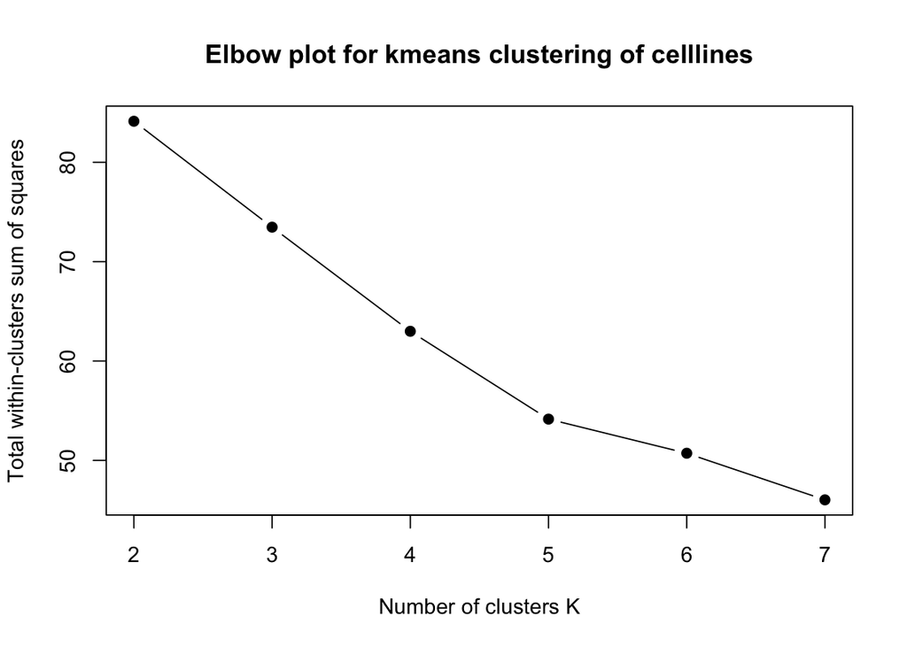

#### Influence of cisplatin on the biomarkers gene expression

The following heatmap shows the influence of cisplatin on up- or downregulation of the biomarkers gene expression. The annotation bar relates cell lines to cancer types, but no patterns between tissues could be found. Genes were be clustered in two main groups:

- 13 genes were mostly upregulated or showed a similar gene expression as in untreated samples
  - LRBA: related to the immune checkpoint CTLA4, leads to a downregulation of immune surveillance
  - CUX1: leads to a downregulation of e.g. the cell cycle
- 2 genes were mostly downregulated upon cisplatin pertubation
  - GMDS: GMDS mutation/deficiency is said to be important for the escape from NK cell mediated tumor surveillance

As cisplatin acts as an intrastrand DNA-crosslinker, the targeted cells are not tumor-specific. Therefore this inconclusive result of gene up- and downregulation could be caused by the presence of more necrotic cells in the tumor microenvironment, which attract other immune cells and therefore brings other tumor cells to downregulate immune surveillance upon cisplatin treatment.

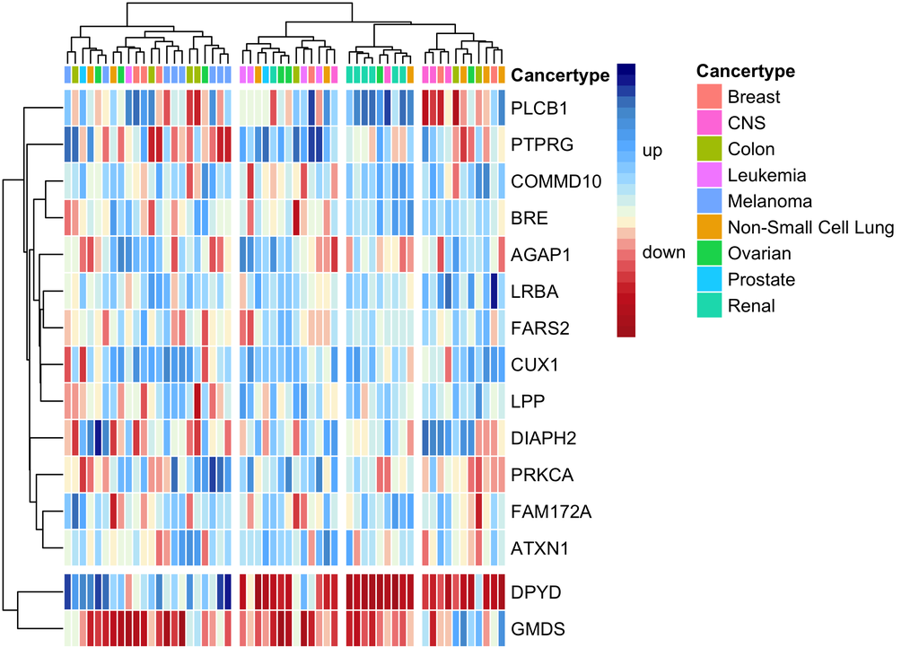

```r
colnames(double.biomarker.FC) <- meta[95:149,2]
annotation = data.frame(Cancertype = cellline$Cancer_type)
rownames(annotation) = cellline$Cell_Line_Name

pheatmap(double.biomarker.FC,
         color = colfunc(25),
         cluster_cols = TRUE,
         clustering_rows = TRUE,
         clustering_method ="ward.D2",
         treeheight_row = 30,
         treeheight_col = 30,
         annotation_col = annotation,
         legend = T,
         legend_breaks = c(-1,1),
         legend_labels = c("down", "up"),
         show_colnames = F,
         cutree_rows = 2,
         cutree_cols = 4,
         border_color = "white",
         scale = "column")
```

## Step 3: Further analysis of the biomarkers

Finally we evaluated whether there is an amplification, deletation or neutral gene copy number. Any values smaller than -1 indicate a deletation and values higher than 1 an amplification. All values in between -1 and 1 represent a neutral gene copy number. [Source: Description of data sets](https://github.com/datascience-mobi/02-cellular-response-to-drug-pertubations#description-of-data-sets).

```r
copynumber.biomarker = as.matrix(copynumber[double.biomarker,])
copynumber.quali = ifelse(copynumber.biomarker <= (-1), (-1), ifelse (copynumber.biomarker >= (1), 1, 0))
```

The following plot visualizes the distribution of genetic alterations throughout the cell lines for the biomarker genes.

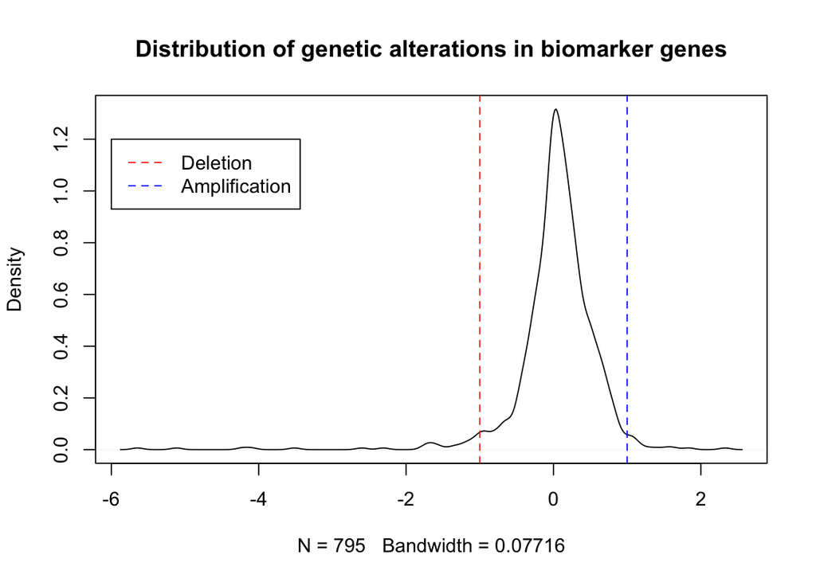

All cell lines were evaluated and related to tissue and cancer types. The result was visualized in a heatmap, which was clustered with kmeans-clustering.

#### Checking the optimal number of cluster (elbow plot)

Before the heatmap was computed, the optimal number of clusters was checked with an elbow plot.

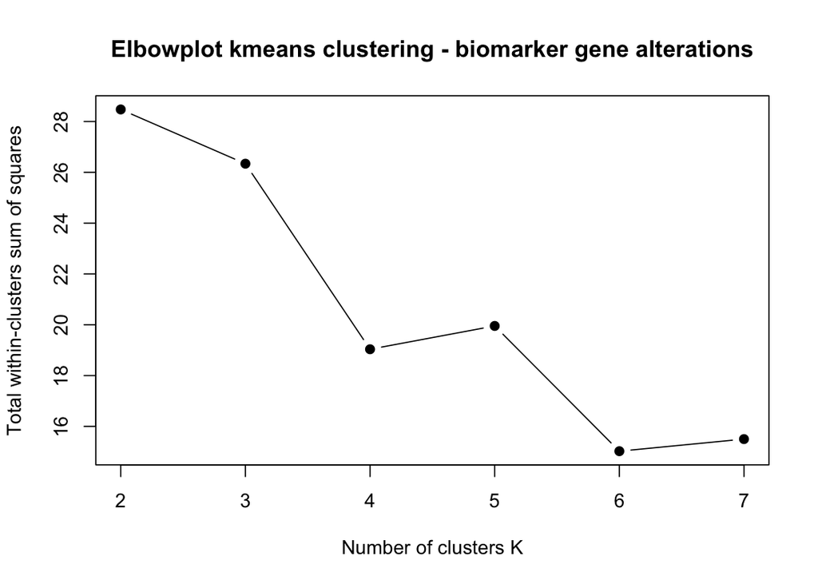

```
## [1] 16.40351
```

### Connection between biomarker and genetic alterations

Overall, biomarker genes for cisplatin do not show many genetic alterations. An exception to this general trend is e.g. the gene LRBA, which is said to be important for immune regulation. This result seems to be reasonable, as cisplatin is an unspecific chemotherapy agent, which is why biomarker genes for cisplatin are not generally alterated.

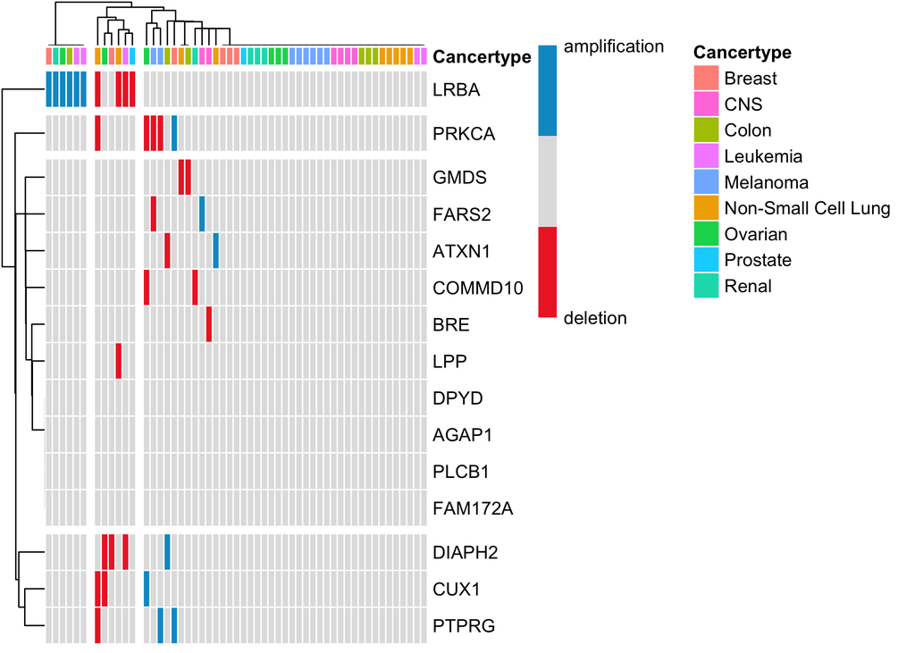

## Sources

“The NCI Transcriptional Pharmacodynamics Workbench: A Tool to Examine Dynamic Expression Profiling of Therapeutic Response in the NCI-60 Cell Line Panel.”, Monks et. al.